# Calculating disease severity by adjusting for delays between onset and outcome during an outbreak

# Overview

This vignette outlines how to use `datadelay` to calculate disease severity during an ongoing outbreak. We wish to estimate one of the typical severity quantities used in epidemiology: the *case fatality risk (CFR)*, *infection hospitality risk (IFR)* or *hospitalisation fatality risk (HFR)*. We do so using a method that uses a time series of cases, infections of hospitalisations (respectively) and deaths with an appropriate delay distribution. The methods used here originate from Nishiura et al. (2009)<sup>[1]</sup>.

This vignette demonstrates how to implement the core functions within `datadelay`. Specifically, we will cover

1. Why naive estimates of CFR or HFR generated during an ongoing outbreak require adjusting, given out of sync time series are often being compared.
2. Arrive at estimates over time for the number of symptomatic individuals that will likely be known to have had an outcome $t$ days after symptom onset
3. Define an unbiased estimator to estimate the CFR or HFR from Nishiura et al (2009)<sup>[1]</sup>
4. Numerically implement the unbiased estimator numerically using maximum likelihood estimation to arrive at central estimates of the CFR or HFR, along with a confidence interval.

```r
library(datadelay)
library(epiparameter)
library(covidregionaldata)
library(knitr)
library(kableExtra)
```

# Motivation

Key epidemiological quantities estimated in real-time often suffer from biases. In particular, dividing deaths-to-date by cases-to-date, infections-to-date or hospitalisations-to-date leads to biased estimates of the CFR, IFR or HFR (respectively). This is because this calculation does not account for delays from confirmation of a case, infection or hospitalisation-to-death.

If we had perfectly synchronised case and death incidence data, the basic versions of the CFR, IFR and HFR — defined as either the ratio of the total number of deaths and the total number of cases, infections or hospitalisations — would be accurate. These basic estimates are referred to as naive estimators. However, due to delays between onset or hospitalisation and death for all known diseases, this synchronisation is never true.

For example, suppose 10 people start showing symptoms of a specific disease on a given day and the end of that day all remain alive. Suppose that for the next 5 days, the numbers of new cases continue to rise until they reach 100 new cases on day 5. However, suppose that by day 5, all infected individuals remain alive. The naive estimate of the CFR would be zero calculated at the end of the first 5 days would be zero, because there would have been zero deaths in total. Even after deaths begin to occur, this lag between the ascertainment of a case or hospitalisation and outcome leads to a consistently biased estimate. Hence, adjusting for such delays using an appropriate delay distribution is essential for accurate estimates of severity.

# Methods

## Data required

The data required to estimate the severity of a disease during an ongoing outbreak using the `datadelay` package includes:

- A time-series of cases, hospitalisations or some other proxy for infections over time;
- A time-series of deaths;
- A delay distribution, describing the probability an individual will die $t$ days after they were initially exposed. Such distributions come from the literature, where studies have typically fit distributions to data describing the process.

In practice, the time-series of cases and deaths will already be together, given that they usually originate from sources that will have typically collated them into a single data file.

The function within `datadelay` used to estimate the severity of a disease at a single time-point — `estimate_static()` — requires a `data.frame` of input data — typically case and death time series data — and a delay distribution. The delay distribution we use here comes from the `epiparameter` package.

## Adjusting for delays between the two time series

The method used by this function follows Nishiura et al.<sup>[1]</sup>. The function calculates a quantity $u_t$ for each day within the input data, which represents the proportion of cases with a known outcome, on day $t$. Following Nishiura et al., $u_t$ is calculated in the following way:

$$\begin{equation}
u_t = \frac{\sum_{i = 0}^t
\sum_{j = 0}^\infty c_i f_{j - i}}{\sum_{i = 0} c_i},
\end{equation}$$

where $f_t$ is the value of the probability mass function at time $t$ and $c_t$, $d_t$ are the number of new cases and new deaths at time $t$, (respectively). We then use $u_t$ at the end of the outbreak in the following likelihood function to estimate the severity of the disease in question.

$$\begin{equation}
L(\theta | y) = \log{\binom{u_tC}{D}} + D \log{\theta} +
(u_tC - D)\log{(1.0 - \theta)},
\end{equation}$$

$C$ and $D$ are the cumulative number of cases and deaths (respectively) up until time $t$. Lastly, $\theta$ is the parameter we wish to estimate, the severity of the disease. We estimate $\theta$ using simple maximum-likelihood methods, allowing the functions within this package to be quick and easy tools to use.

## Interpreting the estimates

The precise severity measure — CFR, IFR, HFR, etc — that represents depends upon the input data given by the user. For complete clarity, here are the most common time series that users might calculate severity from and the resulting severity estimate from such data:

- Case and death incidence data, with a case-to-death delay distribution (or close approximation, such as onset-to-death) — Case Fatality Risk (CFR).
- Infection and death incidence data, with an exposure-to-death delay distribution (or close approximation) — Infection Fatality Risk (IFR).
- Hospitalisation and death incidence data, with a hospitalisation-to-death delay distribution (or close approximation) — Hospitalisation Fatality Risk (HFR).

# Example: 1976 Ebola outbreak in The Democratic Republic of the Congo

We use case and death incidence data from the 1976 Ebola outbreak to estimate the overall severity of Ebola. We do so as though we were roughly half way through the outbreak, emulating when the methods presented in this package are arguably their most useful.

First of all, we plot the data from the entire outbreak. Then we subset the data, keeping only the first half of each time series, in order to emulate attempting to calculate the severity of the disease when the effects of long lag-times between case detection and death are most serious.

## Plotting the raw data

First of all, we load the raw data and add the location to it with the following commands:

```r
data("ebola1976")

# Adding the location to the dataset
ebola1976$location <- "Democractic Republic of the Congo"
```

Then, we plot the case incidence data with the following command:

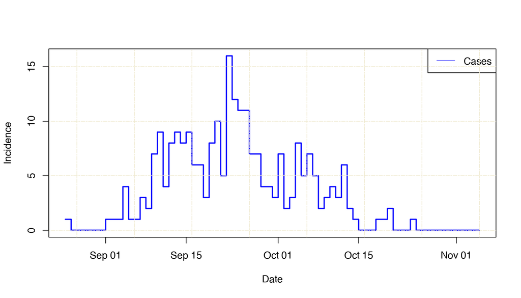

**Figure 1:** Incidence of cases over time, taken from the 1976 Ebola outbreak in the Democratic Republic of the Congo. Data retrieved from within the *datadelay* package

```r
plot_case_data(ebola1976)
```

Lastly, we plot the death incidence data with the following command:

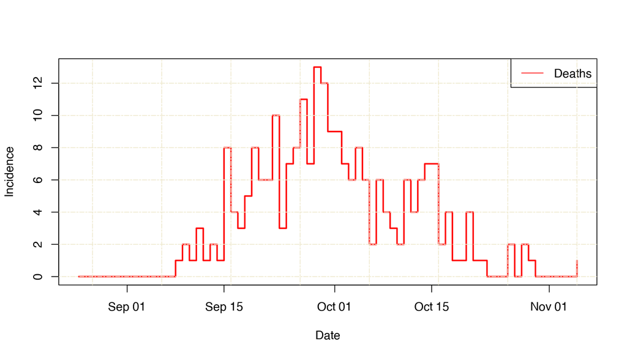

**Figure 2:** Incidence of deaths over time from the same dataset as Figure 1.

```r
plot_death_data(ebola1976)
```

We will focus on the roughly the first half of this dataset. We do so by subsetting the data so that we only include days before the 30th September 1976, using the following command:

```r
df_ebola_subset <- subset(ebola1976, date <= "1976-09-30")
```

## The delay distribution

For this example, given that we are using case data and detection of a case is well-approximated by symptom onset, we use the distribution describing the delay between onset-to-death. As such, we retrieve such a distribution from the literature (reported here<sup>[2]</sup>), using the `epidist_db()` function from the `epiparameter` package with the following command:

```r
onset_to_death_ebola <- epidist_db(
  disease = "Ebola Virus Disease",
  epi_dist = "onset_to_death",
  author = "Barry_etal"
)
```

To visualise this distribution, we evaluate it between 0 and 30 days, and plot the results over time:

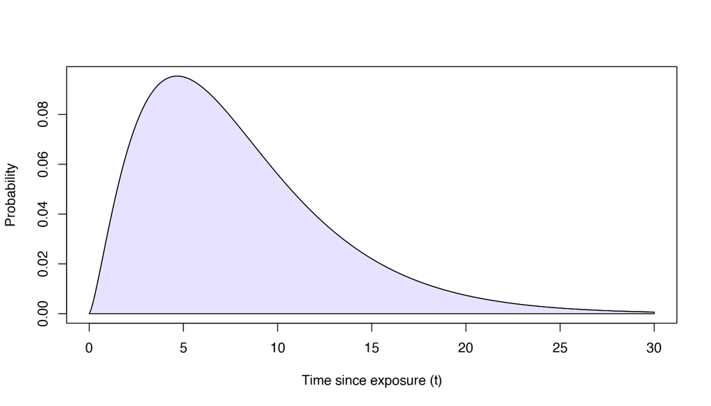

**Figure 3: Example plot of the appropriate delay distribution for the 1976 Ebola dataset.** We plot the onset-to-death distribution we use throughout this example for Ebola Virus Disease (EVD), reported here.

```r
plot_epiparameter_distribution(onset_to_death_ebola, by = 0.1)
```

## Estimating incidence of cases (or similar timeseries) with a known outcome

The function `known_outcomes()` from the `datadelay` package estimates the number of cases which have a known outcome over time.

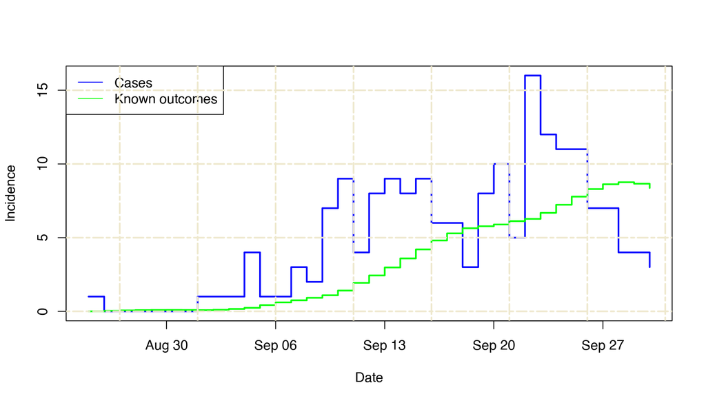

```r
df_known_outcomes_ebola <- known_outcomes(
  df_in = df_ebola_subset,
  epi_dist = onset_to_death_ebola)

plot_known_outcomes(df_known_outcomes_ebola)
```

## Estimating the naive and corrected CFR

Once we calculate the proportion of cases with known outcomes, we apply the proportion to the number of cases to correct for the delay between onset-to-death. We do so by using the function `estimate_static()` from the `datadelay` package. This function estimates the proportion of known outcomes over time, and uses the estimate to correct the naive severity estimate. This is controlled using the `correct_for_delays` boolean flag argument in the `estimate_static` function. Otherwise, it calculates a naive severity estimate, which does not adjust for delays and is simply the total number of deaths in the dataset divided by the total number of cases. We run this function for the naive and corrected estimates using the following two commands (respectively):

```r
# calculating the naive CFR
df_ncfr_static_ebola <- estimate_static(
  df_ebola_subset,
  correct_for_delays = FALSE,
  group_by = "location") |>
  format_output(estimate_type = "severity",
                type = "Naive CFR")

# calculating the corrected CFR
df_ccfr_static_ebola <- estimate_static(
  df_ebola_subset,
  correct_for_delays = TRUE,
  epi_dist = onset_to_death_ebola,
  group_by = "location") |>
  format_output(estimate_type = "severity",
                type = "Corrected CFR")

# putting the two results together
df_static_clean_ebola <- rbind(df_ncfr_static_ebola, df_ccfr_static_ebola)
```

Once we have calculated both the naive and corrected severity estimates, in this case CFRs, we put them together and make a table, using the `kable()` function from the `knitr` package, using the following command:

```r
kable(df_static_clean_ebola,
  align = "c",
  col.names = c("Location", "CFR estimate", "Type")) |>
  kable_styling(full_width = FALSE)
```

| Location | CFR estimate | Type |
| --- | --- | --- |
| Democractic Republic of the Congo | 71.98% (95% CI: 64.86% - 78.37%) | Naive CFR |
| Democractic Republic of the Congo | 100.00% (95% CI: 87.00% - 100.00%) | Corrected CFR |

# Example with data from the ongoing COVID-19 pandemic in the U.K.

We now perform a similar analysis with all of the same steps, with data taken from the ongoing COVID-19 epidemic in the U.K. For brevity, we describe the steps without methodological explanations throughout this example.

## Plotting the raw data

First of all, we subset the data so that we focus on just the first year of the COVID-19 outbreak in the U.K. We do so, as the CFR changed dramatically as a result of the vaccine campaign. The static severity calculations we are performing in this vignette are not able to deal with changes in severity over time. We download the data — using the `covidregionaldata` package — change some default column names to match those required by `datadelay` and subset the data.frame to focus on the first year of the pandemic in the U.K., with the following commands:

```r
df_covid_uk <- get_national_data(
  countries = "united kingdom", source = "who", verbose = FALSE)

names(df_covid_uk)[names(df_covid_uk) == "cases_new"] <- "cases"
names(df_covid_uk)[names(df_covid_uk) == "deaths_new"] <- "deaths"

df_covid_uk_subset <- subset(df_covid_uk, date <= "2020-12-31")
```

Then, we plot the subsetted case data with following command:

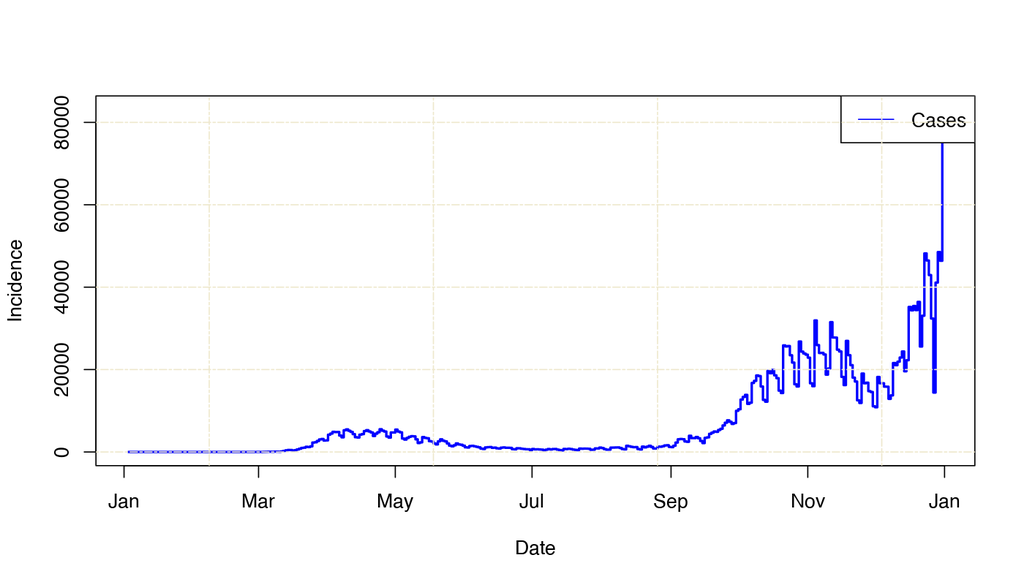

**Figure 5:** Incidence of cases over time for the ongoing COVID-19 outbreak in the U.K.

```r
plot_case_data(df_covid_uk_subset)
```

Then, we plot the subsetted death data with following command:

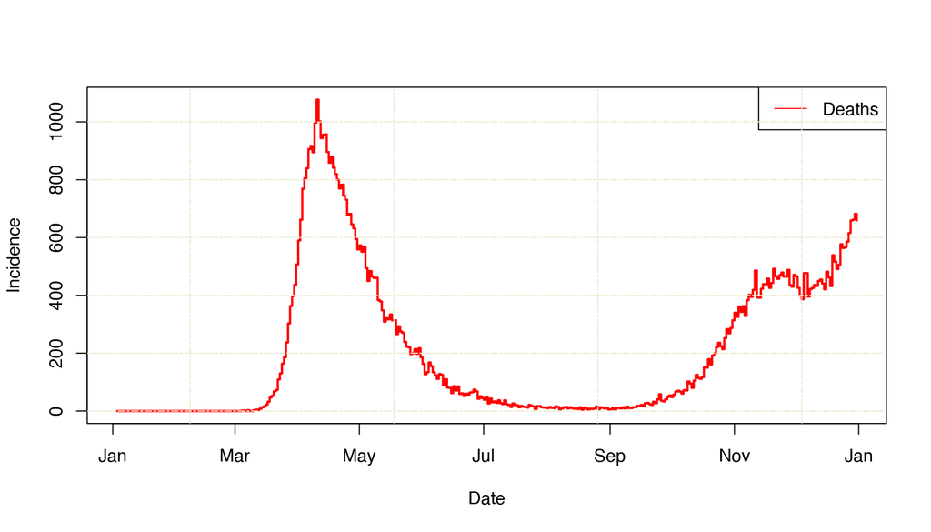

**Figure 6:** Incidence of deaths over time for the ongoing COVID-19 outbreak in the U.K.

```r
plot_death_data(df_covid_uk_subset)
```

## The delay distribution

We again retrieve the appropriate distribution (reported [here](https://doi.org/10.3390/jcm9020538)<sup>[3]</sup>), using the `epidist_db()` function from the `epiparameter` package, using the following command:

```r
onset_to_death_covid <- epidist_db(
  disease = "COVID-19",
  epi_dist = "onset_to_death",
  author = "Linton_etal"
)
```

To visualise this distribution, we evaluate it between 0 and 30 days, and plot the results over time. We do so using the following command:

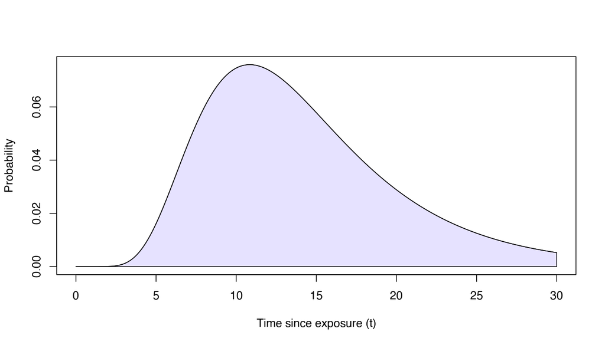

**Figure 7: Example plot of the appropriate delay distribution for the COVID-19 epidemic in the U.K.** We plot the onset-to-death distribution we use throughout this example for COVID-19, reported [here](https://doi.org/10.3390/jcm9020538).

```r
plot_epiparameter_distribution(onset_to_death_covid, by = 0.1)
```

## Estimating incidence of cases (or similar timeseries) with a known outcome

We use the same method and implementation as in the Ebola example to calculate the number of known outcomes over time, using the following command:

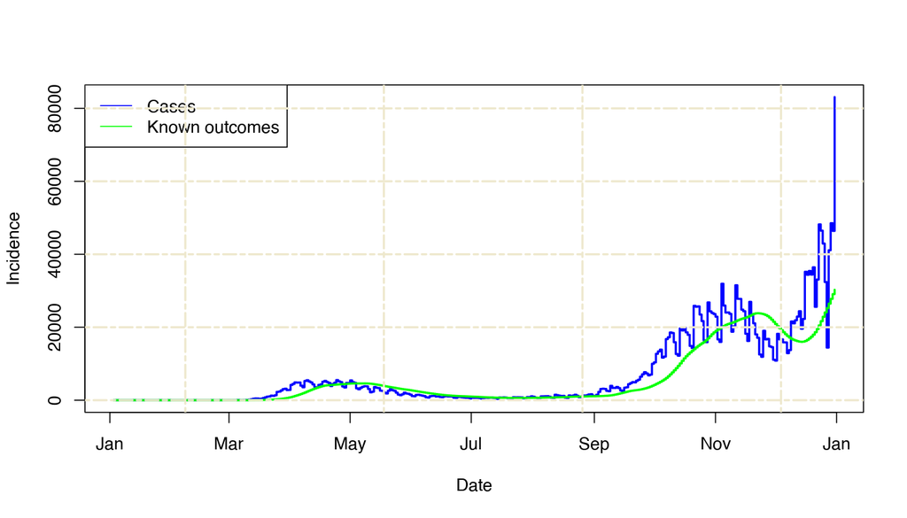

**Figure 8:** The same case time series for the ongoing COVID-19 epidemic in the U.K., with estimated known outcomes included.

```r
df_known_outcomes_covid <- known_outcomes(
  df_in = df_covid_uk_subset,
  epi_dist = onset_to_death_covid
)

plot_known_outcomes(df_known_outcomes_covid)
```

## Estimating the naive and corrected CFR

Finally, we calculate the naive and corrected CFRs for the COVID-19 epidemic in the U.K:

```r
# calculating the naive CFR
df_ncfr_static_covid <- estimate_static(
  df_covid_uk_subset,
  correct_for_delays = FALSE,
  group_by = "country") |>
  format_output(
    estimate_type = "severity", type = "Naive CFR")

# calculating the corrected CFR
df_ccfr_static_covid <- estimate_static(
  df_covid_uk_subset,
  correct_for_delays = TRUE,
  epi_dist = onset_to_death_covid,
  group_by = "country") |>
  format_output(estimate_type = "severity", type = "Corrected CFR")

# putting the two results together
df_static_clean_covid <- rbind(df_ncfr_static_covid, df_ccfr_static_covid)
```

Once we have calculated both the naive and corrected CFR values, we put them together and make a table, using the `kable()` function from the `knitr` package, using the following command:

```r
kable(df_static_clean_covid,
  align = "c",
  col.names = c("Location", "CFR estimate", "Type")) |>
  kable_styling(full_width = FALSE)
```

| Location | CFR estimate | Type |
| --- | --- | --- |
| United Kingdom | 2.93% (95% CI: 2.91% - 2.96%) | Naive CFR |
| United Kingdom | 3.70% (95% CI: 3.70% - 3.80%) | Corrected CFR |

1

Nishiura H, Klinkenberg D, Roberts M, *et al.* Early epidemiological assessment of the virulence of emerging infectious diseases: A case study of an influenza pandemic. *PloS one* 2009;**4**:e6852.

2

Barry A, Ahuka-Mundeke S, Ahmed YA, *et al.* Outbreak of ebola virus disease in the democratic republic of the congo, april–may, 2018: An epidemiological study. *The Lancet* 2018;**392**:213–21.

3

Linton NM, Kobayashi T, Yang Y, *et al.* Incubation period and other epidemiological characteristics of 2019 novel coronavirus infections with right truncation: A statistical analysis of publicly available case data. *Journal of clinical medicine* 2020;**9**:538.